# Requirements

#### Predictions

In this section, I will proceed to predict values from the evaluation data set.

##### Evaluation data transformations

In this section I will transform our evaluation data same as our original data has.

##### Predict TARGET_FLAG

In this section, I will predict the probability of having an accident or no accident and categorize it in the TARGET_FLAG variable.

**Accident Predictions Table**

In this section, I will predict the values on the **evaluation** data set employing the **training** data set.

Let’s see a table for the first 20 records.

|  | INDEX | TARGET_FLAG |
| --- | --- | --- |
| 1 | 3 | 0 |
| 2 | 9 | 0 |
| 3 | 10 | 0 |
| 4 | 18 | 0 |
| 5 | 21 | 0 |
| 6 | 30 | 0 |
| 7 | 31 | 0 |
| 8 | 37 | 0 |
| 9 | 39 | 0 |
| 10 | 47 | 0 |

[output cut: 10 more lines]

**Predict TARGET_AMT**

In this section, I will predict the amount based on the final linear model selected. In order to accomplish this goal, I need to do as follows:

Since there’s no way to indicate if the new values are considered outliers or not, I will assign a zero instead; then I will re-evaluate with the given values.

- data.eval$BLUEBOOK_Outlier <- 0
- data.eval$INCOME_Outlier <- 0
- data.eval$HOME_VAL_Outlier <- 0

Let’s see the first 20 records of the first run for the predicted data set.

|  | INDEX | TARGET_FLAG | TARGET_AMT |
| --- | --- | --- | --- |
| 1 | 3 | 0 | 0.00 |
| 2 | 9 | 0 | 0.00 |
| 3 | 10 | 0 | 0.00 |
| 4 | 18 | 0 | 0.00 |
| 5 | 21 | 0 | 0.00 |
| 6 | 30 | 0 | 0.00 |
| 7 | 31 | 0 | 0.00 |
| 8 | 37 | 0 | 0.00 |
| 9 | 39 | 0 | 0.00 |
| 10 | 47 | 0 | 0.00 |

[output cut: 10 more lines]

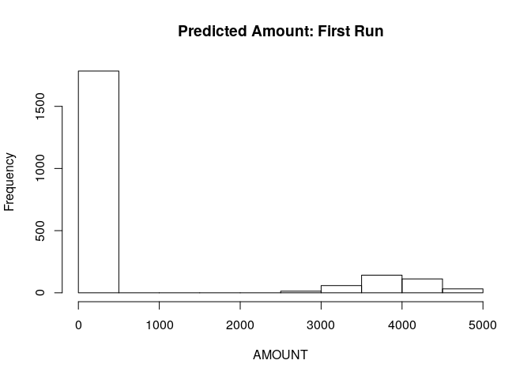

Now, the above values were calculated assuming that all outliers were ZERO. Let’s recalculate and see if new Outliers can be found in order to refine our values.

```
##    Min. 1st Qu.  Median    Mean 3rd Qu.    Max.
##     0.0     0.0     0.0   646.2     0.0  4932.3
```

Let’s see the first 40 records of the final predicted data set.

|  | INDEX | TARGET_FLAG | TARGET_AMT |
| --- | --- | --- | --- |
| 1 | 3 | 0 | 0.00 |
| 2 | 9 | 0 | 0.00 |
| 3 | 10 | 0 | 0.00 |
| 4 | 18 | 0 | 0.00 |
| 5 | 21 | 0 | 0.00 |
| 6 | 30 | 0 | 0.00 |
| 7 | 31 | 0 | 0.00 |
| 8 | 37 | 0 | 0.00 |
| 9 | 39 | 0 | 0.00 |
| 10 | 47 | 0 | 0.00 |

[output cut: 30 more lines]

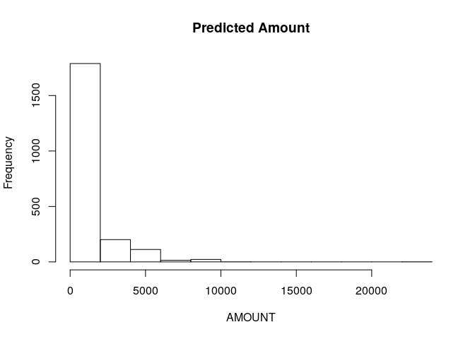

```
##    Min. 1st Qu.  Median    Mean 3rd Qu.    Max.
##     0.0     0.0     0.0   719.6     0.0 23918.2
```

##### Export file

In order to provide a csv output for the predictions table.

```r
write.csv(data.eval_ORIGINAL, file = "insurance-my-evaluated-data.csv",row.names=FALSE)
```

#### Conclusion

In the above example, we can comprehend the importance of understanding the data in order to provide meaningful results. Not all data sets are alike and different approaches need to be taken in order to extract valuable information out of it.

# References

R Core Team. 2016. *R: A Language and Environment for Statistical Computing*. Vienna, Austria: R Foundation for Statistical Computing. https://www.R-project.org/.